# Love Under Lockdown: An investigation into relationship satisfaction in cohabitating couples during the Covid-19 pandemic

Cindy and Kaiting

2025-06-24

# Introduction:

The Covid-19 pandemic has changed our interpersonal relationships and the way we connect with each other. With the onset of Covid-19, much of the world implemented strict social distancing and stay-at-home lockdown orders. This significantly increased the amount of time many couples spent together at home. We were interested in how various stressors exacerbated by the pandemic (financial, housing ratio, and pregnancy) influenced relationship satisfaction over the course of the lockdown. We also wanted to see whether this relationship was mediated by the provision of social support perceived by individuals. This research has important implications for understanding the effects of the pandemic on romantic relationships.

## Database

**Waves:**

The study uses data collected by the Center for Longitudinal Studies and MRC Unit for Lifelong Health and Ageing. They carried out 3 surveys of the participants of 5 national longitudinal cohort studies which collect insights into the lives of study participants on various factors.

Wave 1: May 2020 – at the height of lockdown restrictions

Wave 2: September/October 2020 – period between the easing of restrictions

Wave 3: February/March 2021 – during the third UK lockdown

## Research questions

How did stress influence relationship satisfaction in cohabitating couples during the pandemic?

H1: Stress (financial, pregnancy status, and household ratio) during the pandemic predicts a decline in relationship satisfaction.

H2: Social support mediates the relationship between stress and relationship satisfaction.

# Data cleaning process

First we read the data from the COVID-19 database from the COVID-19 Survey in Five National Longitudinal Cohort Studies. Data cleaning was done based on our research question. We decided to only examine the Next Steps cohort from the database, because it is the only cohort that has social support data and were older than 25 years old to have a higher chance of sustaining stable marriage before the COVID outbreak. Only participants reporting cohabiting with their partner are included to investigate their changes in relationship satisfaction in marriage when having to live with the partner for a longer time during the lockdown.

**Step 1:** include participant based on the inclusion criteria above.

```r
#only include NS participants with cohabiting partner
tar_wave1 <- dat_wave1 %>%
  filter(str_trim(NSID) != "" & CW1_HHNUMWH_1 == "Yes")

tar_wave2 <- dat_wave2 %>%
  filter(str_trim(NSID) != "" & CW2_HHNUMWH_1 == "Yes")

tar_wave3 <- dat_wave3 %>%
  filter(str_trim(NSID) != "" & CW3_HHNUMWH_1 == "Yes")
```

**Step 2:** Variables selection after merging dataset from different waves

*Variables:*

COVID-related stressor: financial stressor, pregnancy status, and personal space.

Protective factor: social support.

Outcome variable: relationship satisfaction.

We chose the stressor variables based on prior research associating these stressors to relationship strain. Furthermore, these were all factors that are highly significant during Covid-19 (ie financial stress increased since many people lost their jobs, pregnancy status due to uncertainty and concerns about healthcare, and household ratio since people were spending more time at home and less personal space would likely cause more relationship conflict).

The social support variable was selected, it is a latent factor composed of 3 questions, measuring how perceived support from others. This is based on prior literature highlighting the importance of social support during lockdown.

Example code:

```r
#calculate room-people ratio
tar_wave1$CW1_NUMROOMS <- as.numeric(tar_wave1$CW1_NUMROOMS)
tar_wave1$CW1_HHNUM <- as.numeric(tar_wave1$CW1_HHNUM)
tar_wave1 <- tar_wave1 %>%
  mutate(CW1_PRRATIO = CW1_HHNUM/CW1_NUMROOMS) #denominator cannot be 0 so number of rooms will be the denominator, as there are 0 in CW1_HHNUM

#merge data
all_dat <- bind_rows(tar_wave1, tar_wave2, tar_wave3)
all_dat <- all_dat %>%
  arrange(NSID)

#selected variables
clean_dat <- all_dat %>%
  select(NSID,
         CW1_FINANCIALMAND, CW1_CURPREG, CW1_PRRATIO, CW1_SOCPROV_1, CW1_SOCPROV_2, CW1_SOCPROV_3, CW1_PATIENT, CW1_RELSAT,
         CW2_FINANCIALMAND, CW2_CURPREG, CW2_PRRATIO, CW2_SOCPROV_1, CW2_SOCPROV_2, CW2_SOCPROV_3, CW2_PATIENT, CW2_RELSAT,
         CW3_FINANCIALMAND, CW3_CURPREG, CW3_PRRATIO, CW3_SOCPROV_1, CW3_SOCPROV_2, CW3_SOCPROV_3, CW3_PATIENT, CW3_RELSAT)
```

**Step 3:** changing dataset into wide format for CLPM analysis

Example code:

```r
#changing data into wide format
wide_dat <- clean_dat %>%
  group_by(NSID) %>%
  summarise(across(everything(), ~ first(na.omit(.)), .names = "{.col}"), .groups = "drop")
```

**Step 4:** re-coding data into numeric scales for statistical analysis

Example code:

```r
tab_before <- lapply(
  c("CW1_FINANCIALMAND", "CW1_CURPREG", "CW1_SOCPROV_1", "CW1_SOCPROV_2", "CW1_SOCPROV_3", "CW1_PATIENT", "CW1_RELSAT",
    "CW2_FINANCIALMAND", "CW2_CURPREG", "CW2_SOCPROV_1", "CW2_SOCPROV_2", "CW2_SOCPROV_3", "CW2_PATIENT", "CW2_RELSAT",
    "CW3_FINANCIALMAND", "CW3_CURPREG", "CW3_SOCPROV_1", "CW3_SOCPROV_2", "CW3_SOCPROV_3", "CW3_PATIENT", "CW3_RELSAT"),
  \(var) table(wide_dat[[var]], useNA = "ifany")
)

##take FINANCIALMAND as an example
wide_dat <- wide_dat %>%
  mutate(across(
    c(CW1_FINANCIALMAND, CW2_FINANCIALMAND, CW3_FINANCIALMAND),
    ~ recode(.,
             "No information" = -8,
             "Not applicable" = -1,
             "I’m much worse off" = 1,
             "I’m a little worse off" = 2,
             "I’m about the same" = 3,
             "I’m a little better off" = 4,
             "I’m much better off" = 5,
             "I'm much worse off" = 1,
             "I'm a little worse off" = 2,
             "I'm about the same" = 3,
             "I'm a little better off" = 4,
             "I'm much better off" = 5
             )
  ))
##record another time after re-coding the variables
tab_after <- lapply(
  c("CW1_FINANCIALMAND", "CW1_CURPREG", "CW1_SOCPROV_1", "CW1_SOCPROV_2", "CW1_SOCPROV_3_R", "CW1_PATIENT", "CW1_RELSAT",
    "CW2_FINANCIALMAND", "CW2_CURPREG", "CW2_SOCPROV_1", "CW2_SOCPROV_2", "CW2_SOCPROV_3_R", "CW2_PATIENT", "CW2_RELSAT",
    "CW3_FINANCIALMAND", "CW3_CURPREG", "CW3_SOCPROV_1", "CW3_SOCPROV_2", "CW3_SOCPROV_3_R", "CW3_PATIENT", "CW3_RELSAT"),
  \(var) table(wide_dat[[var]], useNA = "ifany")
)
```

# Data exploration

## Missing data

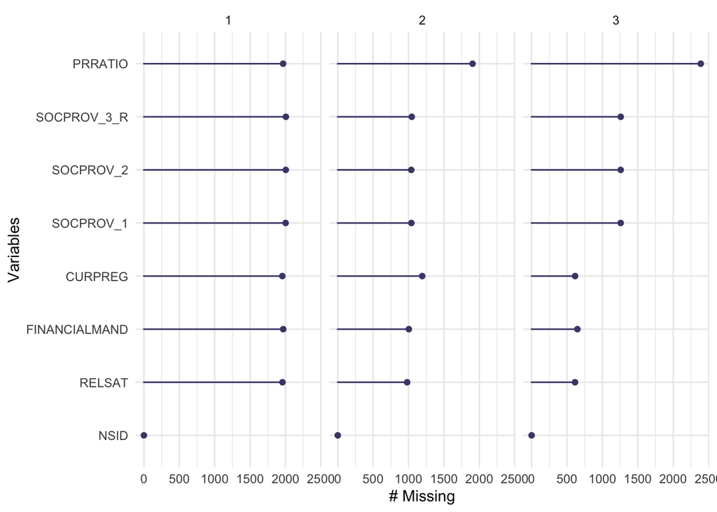

```r
#check missing data
##visualisation of missing data in each variable
gg_miss_var(long_dat, facet = wave)
```

```r
miss_var_summary(wide_dat)
```

```
## # A tibble: 22 × 3
##    variable          n_miss pct_miss
##    <chr>              <int>    <num>
##  1 CW3_PRRATIO         2389     76.4
##  2 CW1_SOCPROV_3_R     2005     64.2
##  3 CW1_SOCPROV_2       2004     64.1
##  4 CW1_SOCPROV_1       2002     64.1
##  5 CW1_FINANCIALMAND   1968     63.0
##  6 CW1_PRRATIO         1966     62.9
##  7 CW1_RELSAT          1957     62.6
##  8 CW1_CURPREG         1955     62.6
##  9 CW2_PRRATIO         1904     60.9
## 10 CW3_SOCPROV_3_R     1259     40.3
## # ℹ 12 more rows
```

```r
long_dat %>%
  group_by(wave) %>%
  summarise(across(where(is.numeric), ~sum(is.na(.)), .names = "{.col}"))
```

```
## # A tibble: 3 × 8
##    wave FINANCIALMAND CURPREG PRRATIO SOCPROV_1 SOCPROV_2 SOCPROV_3_R RELSAT
##   <int>         <int>   <int>   <int>     <int>     <int>       <int>  <int>
## 1     1          1968    1955    1966      2002      2004        2005   1957
## 2     2          1004    1193    1904      1040      1038        1045    980
## 3     3           647     614    2389      1258      1258        1259    613
```

We looked into the exact numbers and proportions of the missing data in each variables, also across waves. Wave 1 was having more missing data compared to 2 and 3, which might be because of many participants are recruited in the later waves. There are excessively missing data in the people room ratio, which suggested a more cautious interpretation of the results is needed for models including this variable. We did not find other thing that is particularly concerning in these results, so we decided to ignore these missing data and just used the remaining data for following analysis. It would be more informative if we have the demographic information of each participant so that we can explore whether if there are particular reasons that are causing these missing data.

## Descriptive statistics

```r
long_dat %>%
  group_by(wave) %>%
  summarise(
    financial_mean = mean(FINANCIALMAND, na.rm = TRUE),
    financial_sd = sd(FINANCIALMAND, na.rm = TRUE),
    preg_mean = mean(CURPREG, na.rm = TRUE),
    preg_sd = sd(CURPREG, na.rm = TRUE),
    pr_mean = mean(PRRATIO, na.rm = TRUE),
    pr_sd = sd(PRRATIO, na.rm = TRUE),
    soc1_mean = mean(SOCPROV_1, na.rm = TRUE),
    soc1_sd = sd(SOCPROV_1, na.rm = TRUE),
    soc2_mean = mean(SOCPROV_2, na.rm = TRUE),
    soc2_sd = sd(SOCPROV_2, na.rm = TRUE),
    soc3_mean = mean(SOCPROV_3_R, na.rm = TRUE),
    soc3_sd = sd(SOCPROV_3_R, na.rm = TRUE),
    rels_mean = mean(RELSAT, na.rm = TRUE),
    rels_sd = sd(RELSAT, na.rm = TRUE)
    )
```

```
## # A tibble: 3 × 15
##    wave financial_mean financial_sd preg_mean preg_sd pr_mean pr_sd soc1_mean
##   <int>          <dbl>        <dbl>     <dbl>   <dbl>   <dbl> <dbl>     <dbl>
## 1     1           2.97        1.01       1.91   0.285   1.08  0.507      1.17
## 2     2           3.02        0.926      1.91   0.285   0.934 0.564      1.19
## 3     3           3.10        1.06       1.90   0.294   0.926 0.554      1.19
## # ℹ 7 more variables: soc1_sd <dbl>, soc2_mean <dbl>, soc2_sd <dbl>,
## #   soc3_mean <dbl>, soc3_sd <dbl>, rels_mean <dbl>, rels_sd <dbl>
```

The means for each variables are quite stable.

## Relationship satisfaction across waves

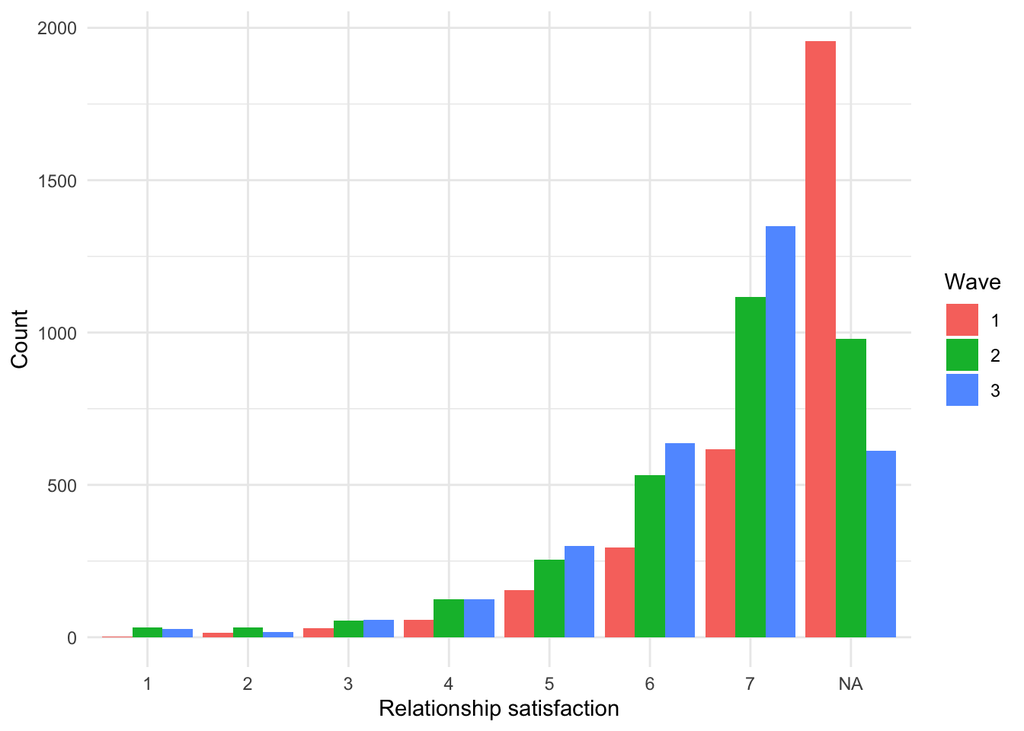

```r
library(ggplot2)
ggplot(long_dat, aes(x = factor(RELSAT), fill = factor(wave))) +
  geom_bar(position = "dodge") +
  labs(x = "Relationship satisfaction", y = "Count", fill = "Wave") +
  theme_minimal()
```

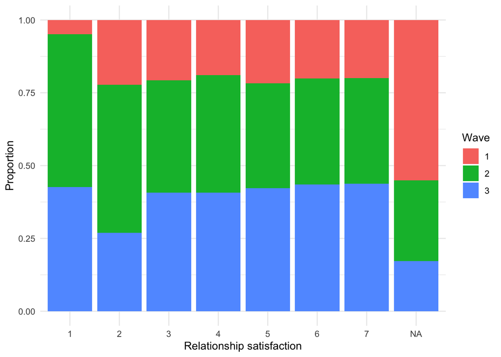

```r
ggplot(long_dat, aes(x = factor(RELSAT), fill = factor(wave))) +
  geom_bar(position = "fill") +
  labs(x = "Relationship satisfaction", y = "Proportion", fill = "Wave") +
  theme_minimal()
```

More people tend to rate higher across each waves. An increased proportion in rating low in wave 2.

## Individual changes to examine the longitudinal trajectories

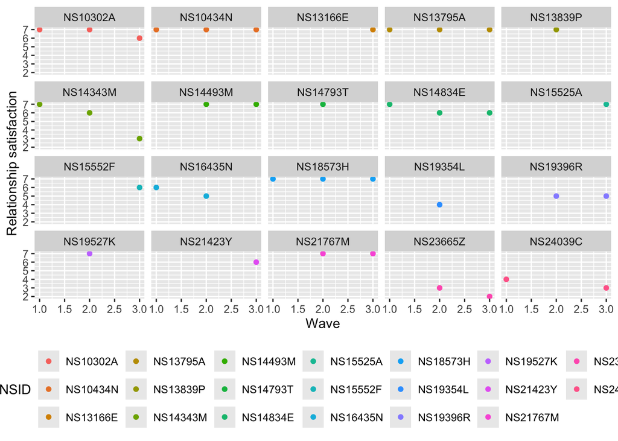

```r
#Individual differences from 20 sample in the dataset
set.seed(12345)
sindex <- sample(unique(long_dat$NSID), 20)

long_dat %>% filter(NSID %in% sindex) %>%
ggplot(., aes(wave, RELSAT, col = NSID)) +
  geom_point() +
  facet_wrap(~ NSID, scales = "fixed") +
  labs(x = "Wave", y = "Relationship satisfaction", col = "NSID") +
  guides(col = guide_legend(nrow = 3)) + theme(legend.position = "bottom")
```

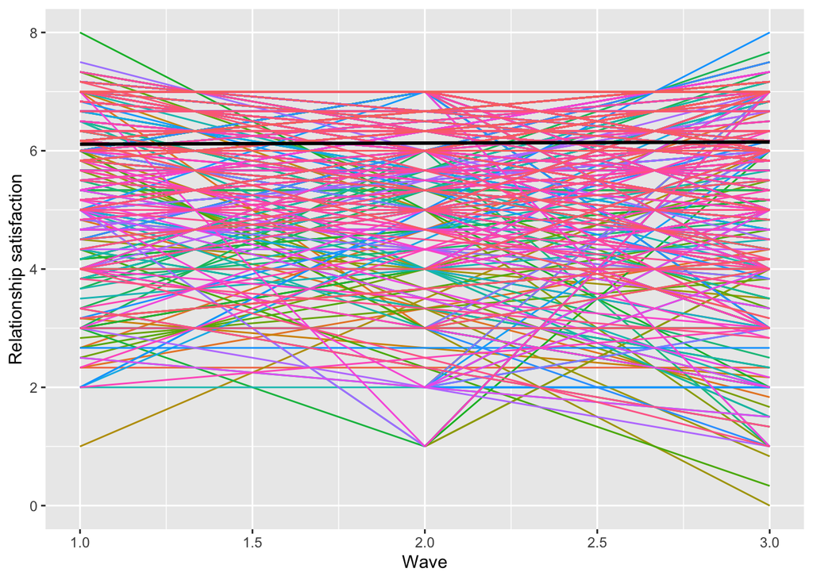

```r
ggplot(long_dat, aes(wave, RELSAT, col = NSID)) +
   geom_smooth(aes(group = NSID), method = "lm", se = FALSE, alpha = .05,  linewidth = .5,) +
   geom_smooth(aes(group = 1), method = "lm", se = FALSE, colour = "black", linewidth = 1) +
  labs(x = "Wave", y = "Relationship satisfaction", col = "NSID") +
  guides(col = guide_legend(nrow = 3)) + theme(legend.position = "none")
```

## Changes of each variables overtime

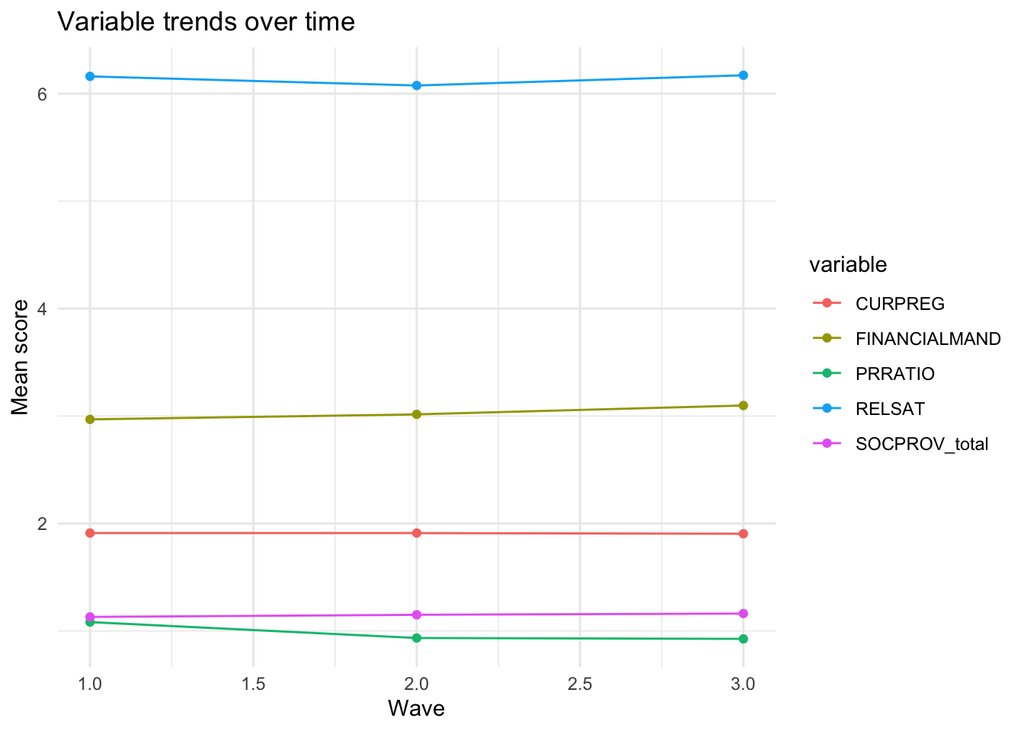

```r
#Cannot visualise anything related to the protected factor as it is a latent factor in the model. To simply explore it a bit, take the mean of social support
long_dat <- long_dat %>%
  mutate(
    SOCPROV_total = rowMeans(select(., c(SOCPROV_1, SOCPROV_2, SOCPROV_3_R))
  ))

long_dat %>%
  group_by(wave) %>%
  summarise(across(c(FINANCIALMAND, CURPREG, PRRATIO, SOCPROV_total, RELSAT), ~mean(., na.rm = TRUE))) %>%
  pivot_longer(-wave, names_to = "variable", values_to = "mean") %>%
  ggplot(aes(x = wave, y = mean, color = variable, group = variable)) +
  geom_line() + geom_point() +
  labs(x = "Wave", y = "Mean score", title = "Variable trends over time") +
  theme_minimal()
```

## Correlation

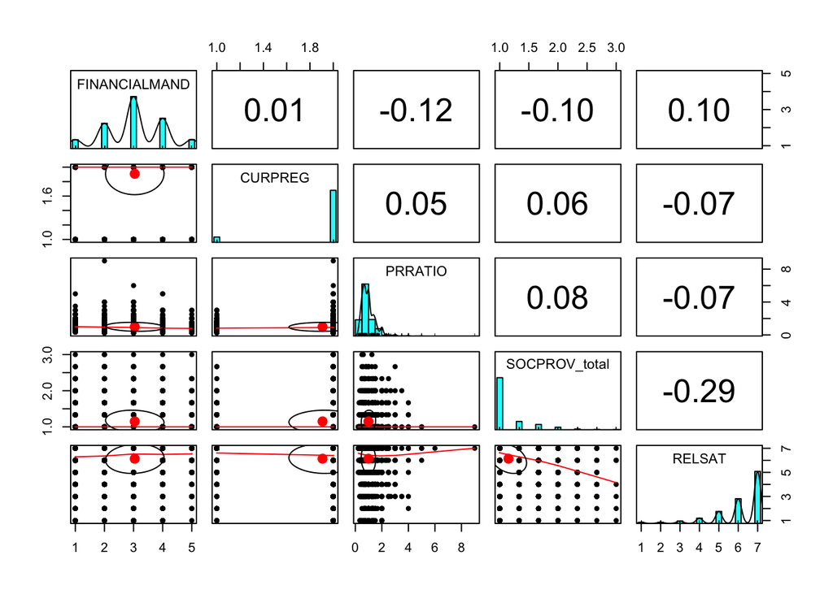

```r
#correlation
vars <- long_dat %>%
  select(FINANCIALMAND, CURPREG, PRRATIO, SOCPROV_total, RELSAT)
pairs.panels(vars)
```

## Correlation matrix across wave

```
## Correlation computed with
## • Method: 'pearson'
## • Missing treated using: 'pairwise.complete.obs'
```

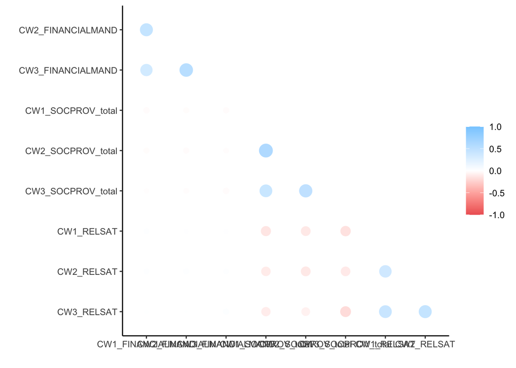

```r
wide_dat <- wide_dat %>%
  mutate(
    CW1_SOCPROV_total = rowMeans(select(., c(CW1_SOCPROV_1, CW1_SOCPROV_2, CW1_SOCPROV_3_R))),
    CW2_SOCPROV_total = rowMeans(select(., c(CW2_SOCPROV_1, CW2_SOCPROV_2, CW2_SOCPROV_3_R))),
    CW3_SOCPROV_total = rowMeans(select(., c(CW3_SOCPROV_1, CW3_SOCPROV_2, CW3_SOCPROV_3_R)))
  )

wide_dat %>%
  select(CW1_FINANCIALMAND, CW2_FINANCIALMAND, CW3_FINANCIALMAND,
         CW1_SOCPROV_total, CW2_SOCPROV_total, CW3_SOCPROV_total,
         CW1_RELSAT, CW2_RELSAT, CW3_RELSAT) %>%
  correlate() %>%
  shave() %>%
  rplot()
```

# Fit model (simple):

## Financial stress and relationship satisfaction

```r
#Simple CLPM testing the model that there might be a causal relationship between financial stress and later relationship satisfaction.

model1 <- '
  # autoregressive paths
  CW2_FINANCIALMAND ~ a1*CW1_FINANCIALMAND
  CW3_FINANCIALMAND ~ a2*CW2_FINANCIALMAND
  CW2_RELSAT ~ b1*CW1_RELSAT
  CW3_RELSAT ~ b2*CW2_RELSAT

  # cross-lagged paths
  CW2_RELSAT ~ c1*CW1_FINANCIALMAND
  CW3_RELSAT ~ c2*CW2_FINANCIALMAND
  CW2_FINANCIALMAND ~ d1*CW1_RELSAT
  CW3_FINANCIALMAND ~ d2*CW2_RELSAT

  # covariances
  CW1_FINANCIALMAND ~~ CW1_RELSAT
  CW2_FINANCIALMAND ~~ CW2_RELSAT
  CW3_FINANCIALMAND ~~ CW3_RELSAT
'

# Fit test using lavvan:
fit1 <- sem(model1, data = wide_dat, missing = "ML", meanstructure = TRUE)
summary(fit1, standardized = TRUE, fit.measures = TRUE)
```

```
## lavaan 0.6-19 ended normally after 54 iterations
##
##   Estimator                                         ML
##   Optimization method                           NLMINB
##   Number of model parameters                        23
##
##                                                   Used       Total
##   Number of observations                          3124        3125
##   Number of missing patterns                        23
##
## Model Test User Model:
##
##   Test statistic                               141.000
##   Degrees of freedom                                 4
##   P-value (Chi-square)                           0.000
##
## Model Test Baseline Model:
##
##   Test statistic                              1876.794
##   Degrees of freedom                                15
##   P-value                                        0.000
##
## User Model versus Baseline Model:
##
##   Comparative Fit Index (CFI)                    0.926
##   Tucker-Lewis Index (TLI)                       0.724
##
##   Robust Comparative Fit Index (CFI)             0.884
##   Robust Tucker-Lewis Index (TLI)                0.566
##
## Loglikelihood and Information Criteria:
##
##   Loglikelihood user model (H0)             -16716.217
##   Loglikelihood unrestricted model (H1)     -16645.717
##
##   Akaike (AIC)                               33478.434
##   Bayesian (BIC)                             33617.512
##   Sample-size adjusted Bayesian (SABIC)      33544.432
##
## Root Mean Square Error of Approximation:
```

[output cut: 53 more lines]

```
##    .CW2_FINANCIALM    1.494    0.144   10.394    0.000    1.494    1.606
##    .CW3_FINANCIALM    1.000    0.113    8.844    0.000    1.000    0.942
##    .CW2_RELSAT        2.504    0.201   12.463    0.000    2.504    1.906
##    .CW3_RELSAT        3.222    0.128   25.128    0.000    3.222    2.708
##     CW1_FINANCIALM    2.906    0.028  104.178    0.000    2.906    2.872
##     CW1_RELSAT        6.162    0.032  194.031    0.000    6.162    5.374
##
## Variances:
##                    Estimate  Std.Err  z-value  P(>|z|)   Std.lv  Std.all
##    .CW2_FINANCIALM    0.632    0.025   25.812    0.000    0.632    0.730
##    .CW3_FINANCIALM    0.758    0.024   31.258    0.000    0.758    0.673
##    .CW2_RELSAT        1.311    0.050   26.194    0.000    1.311    0.759
##    .CW3_RELSAT        1.007    0.032   31.725    0.000    1.007    0.711
##     CW1_FINANCIALM    1.024    0.042   24.556    0.000    1.024    1.000
##     CW1_RELSAT        1.315    0.054   24.434    0.000    1.315    1.000
```

```r
# Model fit: We can see that the fit is okay.. CFI and SRMR are good indicate good/ acceptable fit, but RMSEA and TLI suggest poor fit. Chi square test is statistically significant.
# Autoregressive paths: There are strong and significant autoregressive paths for both financial stress and relationship satisfaction, stability over time.
# Cross-lagged paths: All the cross-lagged paths are non-significant, so in this simple model, financial stress does not predict relationship satisfaction or vice versa. Warrants more exploration of other models and explanations.
# Covariances- Financial stress and relationship satisfaction are consistently correlated with each other within each wave, but do not influence each other causally longitudinally.

#model visualisation
layout_mat <- matrix(NA, nrow=2, ncol=3)
layout_mat[1,1] <- "CW1_FINANCIALMAND"
layout_mat[2,1] <- "CW1_RELSAT"
layout_mat[1,2] <- "CW2_FINANCIALMAND"
layout_mat[2,2] <- "CW2_RELSAT"
layout_mat[1,3] <- "CW3_FINANCIALMAND"
layout_mat[2,3] <- "CW3_RELSAT"

#semlabels <- c("T2 Financial Stress", "T3 Financial Stress", "T2 Relationship Satisfaction", "T3 Relationship Satisfaction", "T1 Financial Stress", "T1 Relationship Satisfaction") ## wanted to relabel the nodes but did not work for now

plt1 <- semPaths(fit1,
         layout = layout_mat,
         whatLabels = "est",
         sizeMan = 9,
         label.cex = 1.2,
         residuals = FALSE,
         intercepts = FALSE,
         edge.label.cex = 1.2,
         nCharNodes = 0,
         fade= TRUE
         )
```

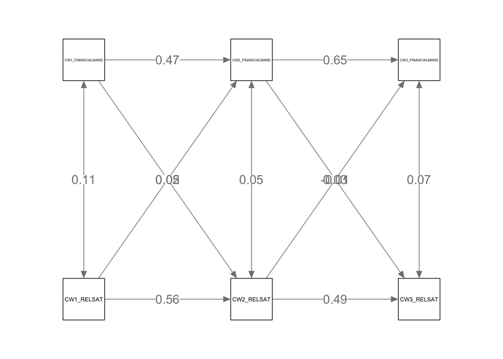

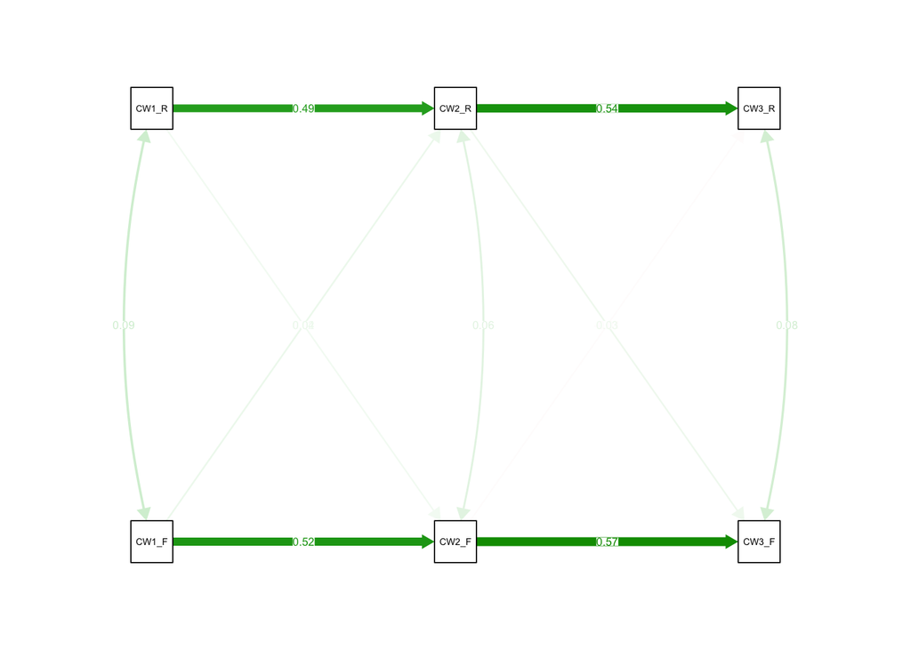

```r
semPaths(fit1,
         what = "std",
         layout = "tree2",
         rotation = 2,
         reorder = FALSE,
         color = list(man = "white"),
         fade= TRUE,
         residuals = FALSE,
         intercepts= FALSE,
         title = FALSE)
```

## Housing ratio and relationship satisfaction

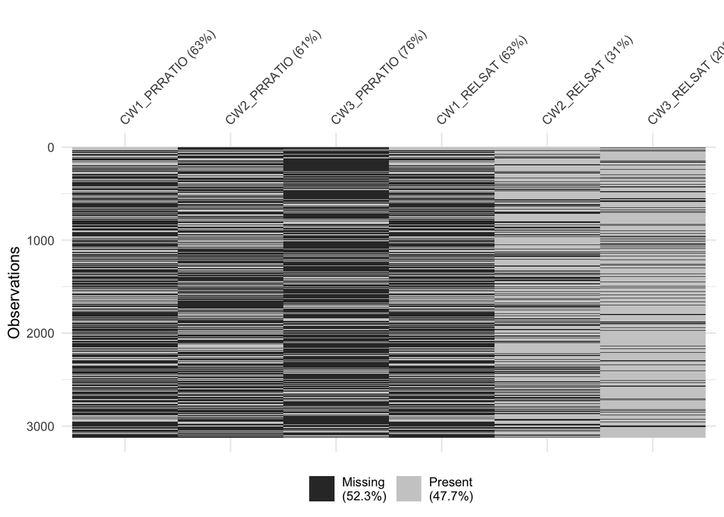

```r
model2 <- '
  # autoregressive paths
  CW2_PRRATIO ~ a1*CW1_PRRATIO
  CW3_PRRATIO ~ a2*CW2_PRRATIO
  CW2_RELSAT ~ b1*CW1_RELSAT
  CW3_RELSAT ~ b2*CW2_RELSAT

  # cross-lagged paths
  CW2_RELSAT ~ c1*CW1_PRRATIO
  CW3_RELSAT ~ c2*CW2_PRRATIO
  CW2_PRRATIO ~ d1*CW1_RELSAT
  CW3_PRRATIO ~ d2*CW2_RELSAT

  # covariances
  CW1_PRRATIO ~~ CW1_RELSAT
  CW2_PRRATIO ~~ CW2_RELSAT
  CW3_PRRATIO ~~ CW3_RELSAT
  '

fit2 <- sem(model2, data = wide_dat, missing = "ML", meanstructure = TRUE)

# Missing data warning, future direction is multiple imputations.

library(naniar)
vis_miss(wide_dat[, c("CW1_PRRATIO", "CW2_PRRATIO", "CW3_PRRATIO",
                      "CW1_RELSAT", "CW2_RELSAT", "CW3_RELSAT")])
```

```r
summary(fit2, standardized = TRUE, fit.measures = TRUE)
```

```
## lavaan 0.6-19 ended normally after 66 iterations
##
##   Estimator                                         ML
##   Optimization method                           NLMINB
##   Number of model parameters                        23
##
##                                                   Used       Total
##   Number of observations                          3124        3125
##   Number of missing patterns                        24
##
## Model Test User Model:
##
##   Test statistic                                88.669
##   Degrees of freedom                                 4
##   P-value (Chi-square)                           0.000
##
## Model Test Baseline Model:
##
##   Test statistic                               910.390
##   Degrees of freedom                                15
##   P-value                                        0.000
##
## User Model versus Baseline Model:
##
##   Comparative Fit Index (CFI)                    0.905
##   Tucker-Lewis Index (TLI)                       0.645
##
##   Robust Comparative Fit Index (CFI)             0.642
##   Robust Tucker-Lewis Index (TLI)               -0.343
##
## Loglikelihood and Information Criteria:
##
##   Loglikelihood user model (H0)             -11502.975
##   Loglikelihood unrestricted model (H1)     -11458.641
##
##   Akaike (AIC)                               23051.951
##   Bayesian (BIC)                             23191.029
##   Sample-size adjusted Bayesian (SABIC)      23117.948
##
## Root Mean Square Error of Approximation:
```

[output cut: 53 more lines]

```
##    .CW2_PRRATIO       1.953    0.266    7.352    0.000    1.953    3.444
##    .CW3_PRRATIO       0.861    0.186    4.624    0.000    0.861    1.549
##    .CW2_RELSAT        2.912    0.215   13.542    0.000    2.912    2.218
##    .CW3_RELSAT        3.469    0.128   27.177    0.000    3.469    2.915
##     CW1_PRRATIO       1.086    0.015   73.005    0.000    1.086    2.144
##     CW1_RELSAT        6.154    0.031  196.503    0.000    6.154    5.375
##
## Variances:
##                    Estimate  Std.Err  z-value  P(>|z|)   Std.lv  Std.all
##    .CW2_PRRATIO       0.235    0.021   11.204    0.000    0.235    0.729
##    .CW3_PRRATIO       0.272    0.019   14.015    0.000    0.272    0.882
##    .CW2_RELSAT        1.317    0.050   26.220    0.000    1.317    0.764
##    .CW3_RELSAT        0.990    0.032   31.319    0.000    0.990    0.699
##     CW1_PRRATIO       0.257    0.011   24.069    0.000    0.257    1.000
##     CW1_RELSAT        1.311    0.053   24.533    0.000    1.311    1.000
```

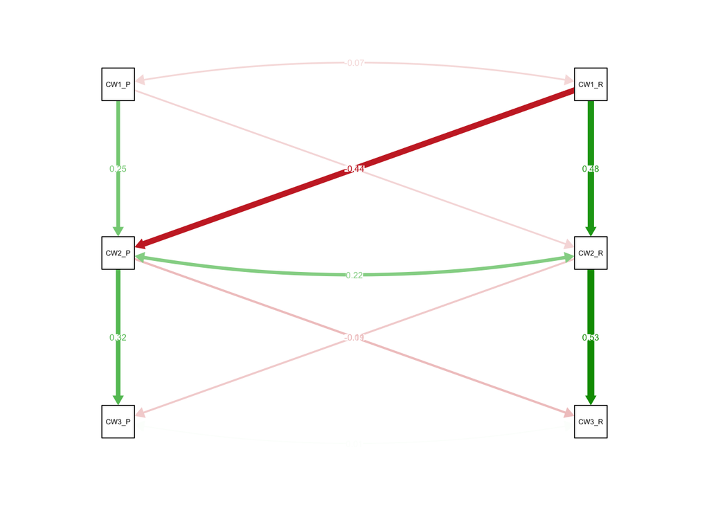

```r
# Model fit is okay, but lots of missing data. CFI >0.9, RMSEA 0.082 (moderate fit), chi square (poor exact fit).
# Autoregressive paths: Significant and stable over time.
# CL paths:  Ratio -> Relsat small but significant negative effect at W1 to W2, stronger W2 to W3. Higher ratio predicts lower future relationship satisfaction, this strengthens over time. Relsat -> Ratio W1 to W2 is strong and significant, this does not really make sense.
# Covariances: Significantly negatively correlated at T1, positively correlated T2, and not significant T3.

semPaths(fit2,
         what = "std",
         layout = "tree2",
         rotation = 1,
         reorder = FALSE,
         color = list(man = "white"),
         fade= TRUE,
         residuals = FALSE,
         intercepts= FALSE,
         title = FALSE)
```

## Pregnancy status and relationship satisfaction

```r
model3 <- '
  # Autoregressive paths
  CW2_CURPREG ~ a1*CW1_CURPREG
  CW3_CURPREG ~ a2*CW2_CURPREG
  CW2_RELSAT ~ b1*CW1_RELSAT
  CW3_RELSAT ~ b2*CW2_RELSAT

  # Cross-lagged paths
  CW2_RELSAT ~ c1*CW1_CURPREG
  CW3_RELSAT ~ c2*CW2_CURPREG
  CW2_CURPREG ~ d1*CW1_RELSAT
  CW3_CURPREG ~ d2*CW2_RELSAT

  # Covariances
  CW1_CURPREG ~~ CW1_RELSAT
  CW2_CURPREG ~~ CW2_RELSAT
  CW3_CURPREG ~~ CW3_RELSAT
'

fit3 <- sem(model3, data = wide_dat, missing = "ML", meanstructure = TRUE)
summary(fit3, standardized = TRUE, fit.measures = TRUE)
```

```
## lavaan 0.6-19 ended normally after 67 iterations
##
##   Estimator                                         ML
##   Optimization method                           NLMINB
##   Number of model parameters                        23
##
##                                                   Used       Total
##   Number of observations                          3124        3125
##   Number of missing patterns                        18
##
## Model Test User Model:
##
##   Test statistic                               150.223
##   Degrees of freedom                                 4
##   P-value (Chi-square)                           0.000
##
## Model Test Baseline Model:
##
##   Test statistic                              1236.790
##   Degrees of freedom                                15
##   P-value                                        0.000
##
## User Model versus Baseline Model:
##
##   Comparative Fit Index (CFI)                    0.880
##   Tucker-Lewis Index (TLI)                       0.551
##
##   Robust Comparative Fit Index (CFI)             0.827
##   Robust Tucker-Lewis Index (TLI)                0.352
##
## Loglikelihood and Information Criteria:
##
##   Loglikelihood user model (H0)              -9865.269
##   Loglikelihood unrestricted model (H1)      -9790.158
##
##   Akaike (AIC)                               19776.538
##   Bayesian (BIC)                             19915.616
##   Sample-size adjusted Bayesian (SABIC)      19842.536
##
## Root Mean Square Error of Approximation:
```

[output cut: 53 more lines]

```
##    .CW2_CURPREG       1.139    0.081   14.136    0.000    1.139    4.008
##    .CW3_CURPREG       1.310    0.056   23.450    0.000    1.310    4.467
##    .CW2_RELSAT        2.610    0.324    8.046    0.000    2.610    1.986
##    .CW3_RELSAT        3.344    0.205   16.339    0.000    3.344    2.810
##     CW1_CURPREG       1.910    0.008  236.336    0.000    1.910    6.688
##     CW1_RELSAT        6.167    0.031  195.807    0.000    6.167    5.379
##
## Variances:
##                    Estimate  Std.Err  z-value  P(>|z|)   Std.lv  Std.all
##    .CW2_CURPREG       0.069    0.003   25.622    0.000    0.069    0.851
##    .CW3_CURPREG       0.077    0.002   33.451    0.000    0.077    0.900
##    .CW2_RELSAT        1.314    0.050   26.189    0.000    1.314    0.761
##    .CW3_RELSAT        1.006    0.032   31.710    0.000    1.006    0.711
##     CW1_CURPREG       0.082    0.003   24.147    0.000    0.082    1.000
##     CW1_RELSAT        1.314    0.054   24.445    0.000    1.314    1.000
```

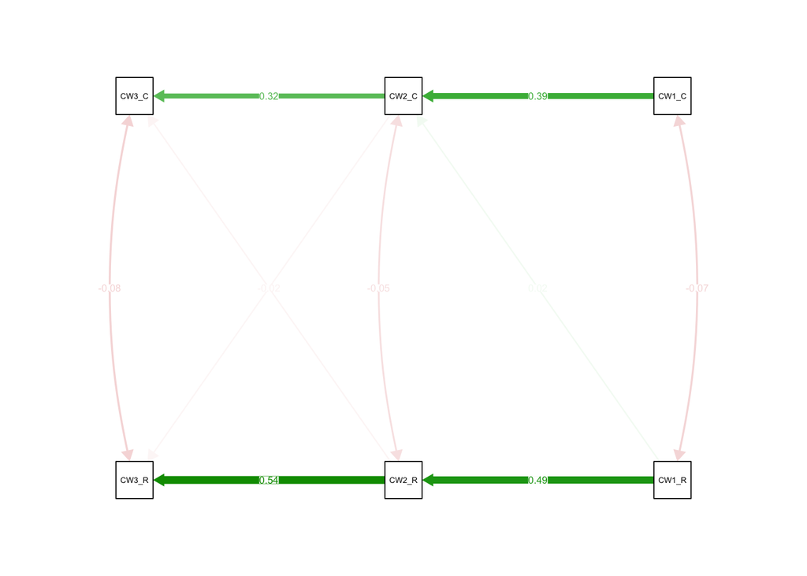

```r
semPaths(fit3,
         what = "std",
         layout = "tree2",
         rotation = 4,
         reorder = FALSE,
         color = list(man = "white"),
         fade= TRUE,
         residuals = FALSE,
         intercepts= FALSE,
         title = FALSE)
```

```r
# Autoregressive: Both pregnancy status and relationship satisfaction are stable across time.
# Cross lagged paths: No significant CL effects.
# Covariances: Negatively correlated at each wave (significant), pregnancy status is associated with lower relationship satisfaction (at the same time), but does not predict longitudinal changes in satisfaction, and vice versa.
```

# More complex models:

We decided to focus on financial stress, and explore more complex models that include social support as a mediator.

```r
#Social support as a mediator between financial stress and relationship satisfaction.
# First, the latent factor (social support) is freely estimated, not constrained to be the same across time.

model11 <- '
# latent factor for social support:
  CW1_SUPPORT =~ CW1_SOCPROV_1 + CW1_SOCPROV_2 + CW1_SOCPROV_3_R
  CW2_SUPPORT =~ CW2_SOCPROV_1 + CW2_SOCPROV_2 + CW2_SOCPROV_3_R
  CW3_SUPPORT =~ CW3_SOCPROV_1 + CW3_SOCPROV_2 + CW3_SOCPROV_3_R

  # Autoregressive paths
  CW2_FINANCIALMAND ~ a1*CW1_FINANCIALMAND
  CW3_FINANCIALMAND ~ a2*CW2_FINANCIALMAND
  CW2_SUPPORT ~ s1*CW1_SUPPORT
  CW3_SUPPORT ~ s2*CW2_SUPPORT
  CW2_RELSAT ~ b1*CW1_RELSAT
  CW3_RELSAT ~ b2*CW2_RELSAT

  # Cross-lagged mediation paths
  CW2_SUPPORT ~ c1*CW1_FINANCIALMAND
  CW3_SUPPORT ~ c2*CW2_FINANCIALMAND
  CW2_RELSAT ~ m1*CW1_SUPPORT
  CW3_RELSAT ~ m2*CW2_SUPPORT

  # Direct effects
  CW2_RELSAT ~ d1*CW1_FINANCIALMAND
  CW3_RELSAT ~ d2*CW2_FINANCIALMAND

# Indirect effects
  indirect21 := c1 * m1
  indirect32 := c2 * m2

  # Covariances
  CW1_FINANCIALMAND ~~ CW1_SUPPORT + CW1_RELSAT
  CW2_FINANCIALMAND ~~ CW2_SUPPORT + CW2_RELSAT
  CW3_FINANCIALMAND ~~ CW3_SUPPORT + CW3_RELSAT
  CW1_SUPPORT ~~ CW1_RELSAT
  CW2_SUPPORT ~~ CW2_RELSAT
  CW3_SUPPORT ~~ CW3_RELSAT
'
#fit model
fit11 <- sem(model11, data = wide_dat, missing = "ML", meanstructure = TRUE)

#model indexes
summary(fit11, standardized = TRUE, fit.measures = TRUE)
```

```
## lavaan 0.6-19 ended normally after 112 iterations
##
##   Estimator                                         ML
##   Optimization method                           NLMINB
##   Number of model parameters                        60
##
##                                                   Used       Total
##   Number of observations                          3124        3125
##   Number of missing patterns                        52
##
## Model Test User Model:
##
##   Test statistic                               437.992
##   Degrees of freedom                                75
##   P-value (Chi-square)                           0.000
##
## Model Test Baseline Model:
##
##   Test statistic                              5971.790
##   Degrees of freedom                               105
##   P-value                                        0.000
##
## User Model versus Baseline Model:
##
##   Comparative Fit Index (CFI)                    0.938
##   Tucker-Lewis Index (TLI)                       0.913
##
##   Robust Comparative Fit Index (CFI)             0.908
##   Robust Tucker-Lewis Index (TLI)                0.872
##
## Loglikelihood and Information Criteria:
##
##   Loglikelihood user model (H0)             -22418.355
##   Loglikelihood unrestricted model (H1)     -22199.359
##
##   Akaike (AIC)                               44956.710
##   Bayesian (BIC)                             45319.522
##   Sample-size adjusted Bayesian (SABIC)      45128.878
##
## Root Mean Square Error of Approximation:
```

[output cut: 114 more lines]

```
##    .CW3_SOCPROV_3_    0.129    0.005   25.979    0.000    0.129    0.667
##    .CW2_FINANCIALM    0.632    0.024   25.806    0.000    0.632    0.729
##    .CW3_FINANCIALM    0.759    0.024   31.258    0.000    0.759    0.673
##    .CW2_RELSAT        1.294    0.050   25.713    0.000    1.294    0.752
##    .CW3_RELSAT        0.995    0.032   31.357    0.000    0.995    0.709
##     CW1_FINANCIALM    1.025    0.042   24.546    0.000    1.025    1.000
##     CW1_RELSAT        1.312    0.054   24.495    0.000    1.312    1.000
##     CW1_SUPPORT       0.068    0.006   10.621    0.000    1.000    1.000
##    .CW2_SUPPORT       0.021    0.003    6.213    0.000    0.310    0.310
##    .CW3_SUPPORT       0.030    0.003    8.893    0.000    0.368    0.368
##
## Defined Parameters:
##                    Estimate  Std.Err  z-value  P(>|z|)   Std.lv  Std.all
##     indirect21       -0.000    0.006   -0.083    0.934   -0.000   -0.000
##     indirect32        0.002    0.004    0.549    0.583    0.002    0.002
```

```r
# Good model fit (CFI = 0.938, TLI = 0.913, RMSEA= 0.039, SRMR= 0.04).
# AR paths: Strong and significant, stable over time.
# CL Effects: Financial -> Support (non-significant); FS -> RS (non-significant); Support -> RS (significant but negative relationship, unexpected).
# No evidence of mediation, non significant FS-> Support-> RS.
```

## Constraining loadings of the latent variable (social support):

```r
#Social support as a mediator between financial stress and relationship satisfaction
model11_lc <- '
# latent factor for social support:
  CW1_SUPPORT =~ l1*CW1_SOCPROV_1 + l2*CW1_SOCPROV_2 + l3*CW1_SOCPROV_3_R
  CW2_SUPPORT =~ l1*CW2_SOCPROV_1 + l2*CW2_SOCPROV_2 + l3*CW2_SOCPROV_3_R
  CW3_SUPPORT =~ l1*CW3_SOCPROV_1 + l2*CW3_SOCPROV_2 + l3*CW3_SOCPROV_3_R

  # Autoregressive paths
  CW2_FINANCIALMAND ~ a1*CW1_FINANCIALMAND
  CW3_FINANCIALMAND ~ a2*CW2_FINANCIALMAND
  CW2_SUPPORT ~ s1*CW1_SUPPORT
  CW3_SUPPORT ~ s2*CW2_SUPPORT
  CW2_RELSAT ~ b1*CW1_RELSAT
  CW3_RELSAT ~ b2*CW2_RELSAT

  # Cross-lagged mediation paths
  CW2_SUPPORT ~ c1*CW1_FINANCIALMAND
  CW3_SUPPORT ~ c2*CW2_FINANCIALMAND
  CW2_RELSAT ~ m1*CW1_SUPPORT
  CW3_RELSAT ~ m2*CW2_SUPPORT

  # Direct effects
  CW2_RELSAT ~ d1*CW1_FINANCIALMAND
  CW3_RELSAT ~ d2*CW2_FINANCIALMAND

# Indirect effects
  indirect21 := c1 * m1
  indirect32 := c2 * m2

  # Covariances
  CW1_FINANCIALMAND ~~ CW1_SUPPORT + CW1_RELSAT
  CW2_FINANCIALMAND ~~ CW2_SUPPORT + CW2_RELSAT
  CW3_FINANCIALMAND ~~ CW3_SUPPORT + CW3_RELSAT
  CW1_SUPPORT ~~ CW1_RELSAT
  CW2_SUPPORT ~~ CW2_RELSAT
  CW3_SUPPORT ~~ CW3_RELSAT
'
#fit model
fit11_lc <- sem(model11_lc, data = wide_dat, missing = "ML", meanstructure = TRUE)
#model indexes
summary(fit11_lc, standardized = TRUE, fit.measures = TRUE)
```

```
## lavaan 0.6-19 ended normally after 105 iterations
##
##   Estimator                                         ML
##   Optimization method                           NLMINB
##   Number of model parameters                        60
##   Number of equality constraints                     4
##
##                                                   Used       Total
##   Number of observations                          3124        3125
##   Number of missing patterns                        52
##
## Model Test User Model:
##
##   Test statistic                               442.049
##   Degrees of freedom                                79
##   P-value (Chi-square)                           0.000
##
## Model Test Baseline Model:
##
##   Test statistic                              5971.790
##   Degrees of freedom                               105
##   P-value                                        0.000
##
## User Model versus Baseline Model:
##
##   Comparative Fit Index (CFI)                    0.938
##   Tucker-Lewis Index (TLI)                       0.918
##
##   Robust Comparative Fit Index (CFI)             0.909
##   Robust Tucker-Lewis Index (TLI)                0.878
##
## Loglikelihood and Information Criteria:
##
##   Loglikelihood user model (H0)             -22420.384
##   Loglikelihood unrestricted model (H1)     -22199.359
##
##   Akaike (AIC)                               44952.767
##   Bayesian (BIC)                             45291.392
##   Sample-size adjusted Bayesian (SABIC)      45113.457
##
```

[output cut: 115 more lines]

```
##    .CW3_SOCPROV_3_    0.130    0.005   26.658    0.000    0.130    0.682
##    .CW2_FINANCIALM    0.632    0.024   25.806    0.000    0.632    0.729
##    .CW3_FINANCIALM    0.759    0.024   31.258    0.000    0.759    0.673
##    .CW2_RELSAT        1.294    0.050   25.720    0.000    1.294    0.752
##    .CW3_RELSAT        0.995    0.032   31.357    0.000    0.995    0.708
##     CW1_FINANCIALM    1.025    0.042   24.545    0.000    1.025    1.000
##     CW1_RELSAT        1.312    0.054   24.499    0.000    1.312    1.000
##     CW1_SUPPORT       0.067    0.005   14.124    0.000    1.000    1.000
##    .CW2_SUPPORT       0.020    0.003    6.371    0.000    0.302    0.302
##    .CW3_SUPPORT       0.031    0.003    9.479    0.000    0.370    0.370
##
## Defined Parameters:
##                    Estimate  Std.Err  z-value  P(>|z|)   Std.lv  Std.all
##     indirect21       -0.001    0.005   -0.129    0.897   -0.001   -0.001
##     indirect32        0.002    0.004    0.572    0.568    0.002    0.002
```

```r
#model comparisons
anova(fit11, fit11_lc) ##not significant, so we can use this constrained model to make sure we are measuring the same latent variable across different time points
```

```
##
## Chi-Squared Difference Test
##
##          Df   AIC   BIC  Chisq Chisq diff     RMSEA Df diff Pr(>Chisq)
## fit11    75 44957 45320 437.99
## fit11_lc 79 44953 45291 442.05     4.0571 0.0021372       4     0.3983
```

```r
#setup layout matrix
layout_matrix <- rbind(
  c(NA, "CW1_FINANCIALMAND", NA, NA, "CW2_FINANCIALMAND", NA, NA, "CW3_FINANCIALMAND", NA),
  c(NA, "CW1_SUPPORT", NA, NA, "CW2_SUPPORT", NA, NA, "CW3_SUPPORT", NA),
  c("CW1_SOCPROV_1", "CW1_SOCPROV_2", "CW1_SOCPROV_3_R", "CW2_SOCPROV_1", "CW2_SOCPROV_2", "CW2_SOCPROV_3_R", "CW3_SOCPROV_1", "CW3_SOCPROV_2", "CW3_SOCPROV_3_R"),
  c(NA, "CW1_RELSAT", NA, NA, "CW2_RELSAT", NA, NA, "CW3_RELSAT", NA)
)

#semlabels <- c("T1 Social Support Q1", "T1 Social Support Q2", "T1 Social Support Q3", "T2 Socual Support Q1", "T2 Socual Support Q2", "T2 Socual Support Q3", "T3 Socual Support Q1", "T3 Socual Support Q2", "T3 Socual Support Q3", "T2 Financial Stress", "T3 Financial Stress", "T2 Relationship Satisfaction", "T3 Relationship Satisfaction", "T1 Financial Stress", "T1 Relationship Satisfaction", "T1 Social Support", "T2 Social Support", "T3 Social Support") ## wanted to relabel the nodes but did not work for now

#model visualisation
plt2 <- semPaths(
  fit11_lc,
  layout = layout_matrix,
  whatLabels = "est",
  edge.label.cex = 0.7,
  sizeMan = 7,
  sizeLat = 7,
  label.cex = 1.2,
  edge.color = "black",
  intercepts = FALSE,
  residuals = FALSE,
  nCharNodes = 0,
  mar = c(8, 4, 8, 4),
  exoCov = FALSE,
  title = FALSE,
  style = "lisrel"
)
```

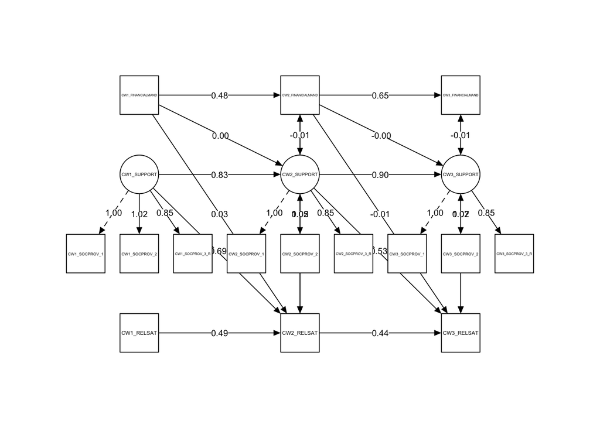

## Constraining autoregressive paths:

Want to test whether the stability of the constructs are consistent over time.

```r
model11AR <- '
# latent factor for social support:
  CW1_SUPPORT =~ l1*CW1_SOCPROV_1 + l2*CW1_SOCPROV_2 + l3*CW1_SOCPROV_3_R
  CW2_SUPPORT =~ l1*CW2_SOCPROV_1 + l2*CW2_SOCPROV_2 + l3*CW2_SOCPROV_3_R
  CW3_SUPPORT =~ l1*CW3_SOCPROV_1 + l2*CW3_SOCPROV_2 + l3*CW3_SOCPROV_3_R

  # Autoregressive paths
  CW2_FINANCIALMAND ~ a*CW1_FINANCIALMAND
  CW3_FINANCIALMAND ~ a*CW2_FINANCIALMAND
  CW2_SUPPORT ~ s*CW1_SUPPORT
  CW3_SUPPORT ~ s*CW2_SUPPORT
  CW2_RELSAT ~ b*CW1_RELSAT
  CW3_RELSAT ~ b*CW2_RELSAT

  # Cross-lagged mediation paths
  CW2_SUPPORT ~ c1*CW1_FINANCIALMAND
  CW3_SUPPORT ~ c2*CW2_FINANCIALMAND
  CW2_RELSAT ~ m1*CW1_SUPPORT
  CW3_RELSAT ~ m2*CW2_SUPPORT

  # Direct effects
  CW2_RELSAT ~ d1*CW1_FINANCIALMAND
  CW3_RELSAT ~ d2*CW2_FINANCIALMAND

# Indirect effects
  indirect21 := c1 * m1
  indirect32 := c2 * m2

  # Covariances
  CW1_FINANCIALMAND ~~ CW1_SUPPORT + CW1_RELSAT
  CW2_FINANCIALMAND ~~ CW2_SUPPORT + CW2_RELSAT
  CW3_FINANCIALMAND ~~ CW3_SUPPORT + CW3_RELSAT
  CW1_SUPPORT ~~ CW1_RELSAT
  CW2_SUPPORT ~~ CW2_RELSAT
  CW3_SUPPORT ~~ CW3_RELSAT
'
#fit model
fit11_AR <- sem(model11AR, data = wide_dat, missing = "ML", meanstructure = TRUE)

#model indexes
summary(fit11_AR, standardized = TRUE, fit.measures = TRUE)
```

```
## lavaan 0.6-19 ended normally after 103 iterations
##
##   Estimator                                         ML
##   Optimization method                           NLMINB
##   Number of model parameters                        60
##   Number of equality constraints                     7
##
##                                                   Used       Total
##   Number of observations                          3124        3125
##   Number of missing patterns                        52
##
## Model Test User Model:
##
##   Test statistic                               475.755
##   Degrees of freedom                                82
##   P-value (Chi-square)                           0.000
##
## Model Test Baseline Model:
##
##   Test statistic                              5971.790
##   Degrees of freedom                               105
##   P-value                                        0.000
##
## User Model versus Baseline Model:
##
##   Comparative Fit Index (CFI)                    0.933
##   Tucker-Lewis Index (TLI)                       0.914
##
##   Robust Comparative Fit Index (CFI)             0.903
##   Robust Tucker-Lewis Index (TLI)                0.876
##
## Loglikelihood and Information Criteria:
##
##   Loglikelihood user model (H0)             -22437.237
##   Loglikelihood unrestricted model (H1)     -22199.359
##
##   Akaike (AIC)                               44980.474
##   Bayesian (BIC)                             45300.958
##   Sample-size adjusted Bayesian (SABIC)      45132.555
##
```

[output cut: 115 more lines]

```
##    .CW3_SOCPROV_3_    0.130    0.005   26.640    0.000    0.130    0.684
##    .CW2_FINANCIALM    0.609    0.023   26.330    0.000    0.609    0.655
##    .CW3_FINANCIALM    0.778    0.025   31.157    0.000    0.778    0.724
##    .CW2_RELSAT        1.307    0.050   26.366    0.000    1.307    0.767
##    .CW3_RELSAT        0.994    0.032   31.448    0.000    0.994    0.704
##     CW1_FINANCIALM    1.002    0.040   25.315    0.000    1.002    1.000
##     CW1_RELSAT        1.313    0.054   24.443    0.000    1.313    1.000
##     CW1_SUPPORT       0.065    0.004   14.828    0.000    1.000    1.000
##    .CW2_SUPPORT       0.019    0.003    6.286    0.000    0.277    0.277
##    .CW3_SUPPORT       0.032    0.003   10.255    0.000    0.388    0.388
##
## Defined Parameters:
##                    Estimate  Std.Err  z-value  P(>|z|)   Std.lv  Std.all
##     indirect21       -0.001    0.006   -0.105    0.917   -0.001   -0.000
##     indirect32        0.002    0.004    0.483    0.629    0.002    0.001
```

```r
#model comparisons
anova(fit11_AR, fit11_lc)
```

```
##
## Chi-Squared Difference Test
##
##          Df   AIC   BIC  Chisq Chisq diff   RMSEA Df diff Pr(>Chisq)
## fit11_lc 79 44953 45291 442.05
## fit11_AR 82 44980 45301 475.76     33.707 0.05724       3  2.285e-07 ***
## ---
## Signif. codes:  0 '***' 0.001 '**' 0.01 '*' 0.05 '.' 0.1 ' ' 1
```

```r
# The results showed that the AR are not equal over time. There is a significant difference between the constrained AR model and constrained AR, the AR model has a significantly higher chi-square, in SEM chi-square measures badness of fit between between the proposed model and the observed data. THe AR paths are not equal over time, so the stability of the varaibles changes across waves. So we won't constrain the AR paths....
```

## Constraining cross-laggged paths:

```r
model11_CL <- '
# latent factor for social support:
  CW1_SUPPORT =~ l1*CW1_SOCPROV_1 + l2*CW1_SOCPROV_2 + l3*CW1_SOCPROV_3_R
  CW2_SUPPORT =~ l1*CW2_SOCPROV_1 + l2*CW2_SOCPROV_2 + l3*CW2_SOCPROV_3_R
  CW3_SUPPORT =~ l1*CW3_SOCPROV_1 + l2*CW3_SOCPROV_2 + l3*CW3_SOCPROV_3_R

  # Autoregressive paths
  CW2_FINANCIALMAND ~ a1*CW1_FINANCIALMAND
  CW3_FINANCIALMAND ~ a2*CW2_FINANCIALMAND
  CW2_SUPPORT ~ s1*CW1_SUPPORT
  CW3_SUPPORT ~ s2*CW2_SUPPORT
  CW2_RELSAT ~ b1*CW1_RELSAT
  CW3_RELSAT ~ b2*CW2_RELSAT

  # Cross-lagged mediation paths
  CW2_SUPPORT ~ c*CW1_FINANCIALMAND
  CW3_SUPPORT ~ c*CW2_FINANCIALMAND
  CW2_RELSAT ~ m*CW1_SUPPORT
  CW3_RELSAT ~ m*CW2_SUPPORT

  # Direct effects
  CW2_RELSAT ~ d1*CW1_FINANCIALMAND
  CW3_RELSAT ~ d2*CW2_FINANCIALMAND

# Indirect effects
  indirect21 := c * m
  indirect32 := c * m

  # Covariances
  CW1_FINANCIALMAND ~~ CW1_SUPPORT + CW1_RELSAT
  CW2_FINANCIALMAND ~~ CW2_SUPPORT + CW2_RELSAT
  CW3_FINANCIALMAND ~~ CW3_SUPPORT + CW3_RELSAT
  CW1_SUPPORT ~~ CW1_RELSAT
  CW2_SUPPORT ~~ CW2_RELSAT
  CW3_SUPPORT ~~ CW3_RELSAT
'

#fit model
fit11_CL <- sem(model11_CL, data = wide_dat, missing = "ML", meanstructure = TRUE)
#model indexes
summary(fit11_CL, standardized = TRUE, fit.measures = TRUE)
```

```
## lavaan 0.6-19 ended normally after 90 iterations
##
##   Estimator                                         ML
##   Optimization method                           NLMINB
##   Number of model parameters                        60
##   Number of equality constraints                     6
##
##                                                   Used       Total
##   Number of observations                          3124        3125
##   Number of missing patterns                        52
##
## Model Test User Model:
##
##   Test statistic                               442.740
##   Degrees of freedom                                81
##   P-value (Chi-square)                           0.000
##
## Model Test Baseline Model:
##
##   Test statistic                              5971.790
##   Degrees of freedom                               105
##   P-value                                        0.000
##
## User Model versus Baseline Model:
##
##   Comparative Fit Index (CFI)                    0.938
##   Tucker-Lewis Index (TLI)                       0.920
##
##   Robust Comparative Fit Index (CFI)             0.909
##   Robust Tucker-Lewis Index (TLI)                0.882
##
## Loglikelihood and Information Criteria:
##
##   Loglikelihood user model (H0)             -22420.729
##   Loglikelihood unrestricted model (H1)     -22199.359
##
##   Akaike (AIC)                               44949.459
##   Bayesian (BIC)                             45275.990
##   Sample-size adjusted Bayesian (SABIC)      45104.409
##
```

[output cut: 115 more lines]

```
##    .CW3_SOCPROV_3_    0.130    0.005   26.656    0.000    0.130    0.681
##    .CW2_FINANCIALM    0.632    0.024   25.815    0.000    0.632    0.729
##    .CW3_FINANCIALM    0.759    0.024   31.256    0.000    0.759    0.674
##    .CW2_RELSAT        1.298    0.050   25.948    0.000    1.298    0.756
##    .CW3_RELSAT        0.994    0.032   31.376    0.000    0.994    0.707
##     CW1_FINANCIALM    1.025    0.042   24.550    0.000    1.025    1.000
##     CW1_RELSAT        1.313    0.054   24.501    0.000    1.313    1.000
##     CW1_SUPPORT       0.067    0.005   14.153    0.000    1.000    1.000
##    .CW2_SUPPORT       0.020    0.003    6.413    0.000    0.304    0.304
##    .CW3_SUPPORT       0.031    0.003    9.449    0.000    0.367    0.367
##
## Defined Parameters:
##                    Estimate  Std.Err  z-value  P(>|z|)   Std.lv  Std.all
##     indirect21        0.001    0.003    0.345    0.730    0.001    0.001
##     indirect32        0.001    0.003    0.345    0.730    0.001    0.001
```

```r
# Model comparison:
anova(fit11_CL, fit11_lc)
```

```
##
## Chi-Squared Difference Test
##
##          Df   AIC   BIC  Chisq Chisq diff RMSEA Df diff Pr(>Chisq)
## fit11_lc 79 44953 45291 442.05
## fit11_CL 81 44949 45276 442.74    0.69147     0       2     0.7077
```

```r
# Model fit is good.
# Model comparison with constrained latent model shows no significant loss of fit, more parsimonious model.
# Strong AR.
# Social Support → Relationship Satisfaction (significant, but negative, unexpected).
# Mediation pathway does not really hold.
# Significant covariances at each point, contemporaneous associations?

#setup layout matrix
layout_matrix <- rbind(
  c(NA, "CW1_FINANCIALMAND", NA, NA, "CW2_FINANCIALMAND", NA, NA, "CW3_FINANCIALMAND", NA),
  c(NA, "CW1_SUPPORT", NA, NA, "CW2_SUPPORT", NA, NA, "CW3_SUPPORT", NA),
  c("CW1_SOCPROV_1", "CW1_SOCPROV_2", "CW1_SOCPROV_3_R", "CW2_SOCPROV_1", "CW2_SOCPROV_2", "CW2_SOCPROV_3_R", "CW3_SOCPROV_1", "CW3_SOCPROV_2", "CW3_SOCPROV_3_R"),
  c(NA, "CW1_RELSAT", NA, NA, "CW2_RELSAT", NA, NA, "CW3_RELSAT", NA)
)

semPaths(
  fit11_CL,
  layout = layout_matrix,
  whatLabels = "est",
  edge.label.cex = 0.7,
  sizeMan = 7,
  sizeLat = 7,
  label.cex = 1.2,
  edge.color = "black",
  intercepts = FALSE,
  residuals = FALSE,
  nCharNodes = 0,
  mar = c(8, 4, 8, 4),
  exoCov = FALSE,
  title = FALSE,
  style = "lisrel"
)
```

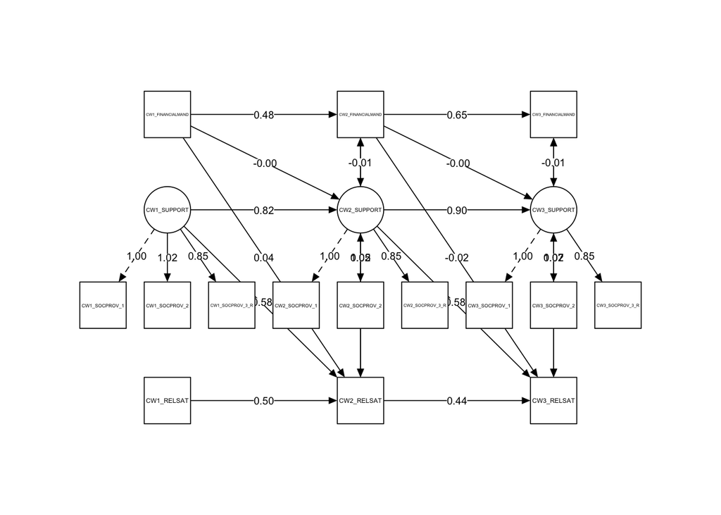

# Conclusion

This longitudinal structural equation modeling study explored how financial stress impacts relationship satisfaction across three waves, with social support as a potential mediator. Further exploration on other factors and models is needed.